# Checkpoint 2: Building and Comparing ICU Mortality Models

Author

Haiyi Xiong

## AI-use statement

I used ChatGPT to help draft and debug R code, organize the modeling workflow, and improve the clarity of the written report. The revised analysis includes executable checks of patient counts, fold assignments, preprocessing and predictions. Results are generated by executing the code and should be reviewed by the author before submission. AI assistance was useful for troubleshooting, but some generated code needed correction, including missing fold labels in saved prediction files. The limitation of this approach is that AI-generated code can contain errors, so I reviewed and revised the results rather than accepting suggestions without checking. I am responsible for the submitted analysis.

## Research question and approach

Can clinical measurements collected during the first 48 hours of an intensive care unit (ICU) stay predict in-hospital mortality? Using set-a only, I compare ridge-penalized logistic regression, a generalized additive model (GAM), and a random forest against the Simplified Acute Physiology Score I (SAPS-I) and Sequential Organ Failure Assessment (SOFA) clinical severity scores. Model discrimination is assessed by area under the receiver operating characteristic curve (AUROC), and probability accuracy by the Brier score. All model predictions used for evaluation are out-of-fold (OOF) predictions.

## 2.1 Modeling table

Each row represents one ICU stay identified by `RecordID`. The outcome is `In-hospital_death`, joined using the `RecordID` in `Outcomes-a.txt`. Patient characteristics are recorded at ICU time 00:00; time-varying predictors summarize observations from hours 0–48 only. This rebuilds the Checkpoint 1 wide-table structure from raw set-a so no previous run is required. Relative to Checkpoint 1, −1 is now treated as missing in all measurements, and non-positive height and weight are excluded. Other extreme measurements are retained without imposing unverified clinical cutoffs; this may affect fitted associations. For repeated clinical observations, I summarize rather than duplicate because repeated measurements describe the trajectory of care.

Summary of the modeling dataset

| ICU_stays | Deaths | Mortality_percent | Predictor_columns |
| --- | --- | --- | --- |
| 4000 | 554 | 13.85 | 221 |

```
Unique RecordIDs: 4000
```

```
Missing outcomes: 0
```

The dataset contains 4000 unique ICU stays, with 554 deaths (13.85%). A one-row-per-stay layout avoids multiple predictions for the same stay and supports direct comparison with SAPS-I and SOFA. The table below is derived exclusively from set-a, and no set-b or set-c files are read.

## 2.2 Predictors

I retain baseline age, gender, height, weight and ICU type; for each dynamic measurement I derive first, last, minimum, maximum, mean and measurement count. These summaries capture initial and recent physiology, extremes, typical levels and monitoring intensity. A measurement count of zero indicates that a measurement was never validly recorded in the observation window. `RecordID` identifies stays but is not a predictor. `Length_of_stay`, `Survival`, SAPS-I and SOFA are not used as features in the three machine learning models.

I prespecified a 98% predictor-missingness exclusion threshold to avoid training on almost entirely unobserved features. The threshold is evaluated within each training split, not using held-out samples; other missing values are handled by training-fold imputation.

Predictor groups and clinical rationale

| Group | Clinical_reason | Number_of_predictors |
| --- | --- | --- |
| Baseline | Baseline patient risk and ICU admission context | 5 |
| First value | Initial physiological condition | 36 |
| Last value | Most recent physiological condition | 36 |
| Maximum | Potentially important high measurements | 36 |
| Mean | Average physiological condition | 36 |
| Measurement count | Monitoring frequency and missingness information | 36 |
| Minimum | Potentially important low measurements | 36 |

Complete candidate predictor inventory

| Group | Predictors |
| --- | --- |
| Baseline | Age, Gender, Height, ICUType, Weight |
| First value | BUN_first, Creatinine_first, GCS_first, Glucose_first, HCO3_first, HCT_first, HR_first, K_first, Mg_first, NIDiasABP_first, NIMAP_first, NISysABP_first, Na_first, Platelets_first, RespRate_first, Temp… |
| Last value | BUN_last, Creatinine_last, GCS_last, Glucose_last, HCO3_last, HCT_last, HR_last, K_last, Mg_last, NIDiasABP_last, NIMAP_last, NISysABP_last, Na_last, Platelets_last, RespRate_last, Temp_last, Urine_la… |
| Maximum | BUN_max, Creatinine_max, GCS_max, Glucose_max, HCO3_max, HCT_max, HR_max, K_max, Mg_max, NIDiasABP_max, NIMAP_max, NISysABP_max, Na_max, Platelets_max, RespRate_max, Temp_max, Urine_max, WBC_max, Dias… |
| Mean | BUN_mean, Creatinine_mean, GCS_mean, Glucose_mean, HCO3_mean, HCT_mean, HR_mean, K_mean, Mg_mean, NIDiasABP_mean, NIMAP_mean, NISysABP_mean, Na_mean, Platelets_mean, RespRate_mean, Temp_mean, Urine_me… |
| Measurement count | BUN_count, Creatinine_count, GCS_count, Glucose_count, HCO3_count, HCT_count, HR_count, K_count, Mg_count, NIDiasABP_count, NIMAP_count, NISysABP_count, Na_count, Platelets_count, RespRate_count, Temp… |
| Minimum | BUN_min, Creatinine_min, GCS_min, Glucose_min, HCO3_min, HCT_min, HR_min, K_min, Mg_min, NIDiasABP_min, NIMAP_min, NISysABP_min, Na_min, Platelets_min, RespRate_min, Temp_min, Urine_min, WBC_min, Dias… |

Ten most frequently unmeasured variables

| Measurement | Never_measured_percent |
| --- | --- |
| TroponinI | 94.9 |
| Cholesterol | 92.4 |
| TroponinT | 78.4 |
| RespRate | 72.5 |
| Albumin | 59.6 |
| ALP | 57.8 |
| ALT | 57.0 |
| Bilirubin | 57.0 |
| AST | 56.9 |
| SaO2 | 55.2 |

The feature-group table lists 221 candidate predictors. The missingness table measures the fraction of stays with no valid observation for each parameter, not the proportion of missing hourly readings. For example, TroponinI is unmeasured in approximately 94.9% of stays. A zero measurement count retains this clinically relevant pattern. No variables are dropped using outcome information.

## 2.3 Cross-validation design

I use stratified five-fold cross-validation (CV), with mortality as the stratification variable and the ICU stay as the splitting unit. There is only one row per stay, so `RecordID` cannot appear simultaneously in training and validation. Exactly the same outer folds are used for all three fitted models and both clinical benchmarks. Predictor filtering, imputation, encoding and scaling are fitted only on training data, then applied to held-out data.

Stratified five-fold cross-validation design

| Fold | Training_stays | Validation_stays | Training_deaths | Validation_deaths | Validation_death_pct | Overlapping_IDs |
| --- | --- | --- | --- | --- | --- | --- |
| Fold1 | 3199 | 801 | 443 | 111 | 13.86 | 0 |
| Fold2 | 3200 | 800 | 443 | 111 | 13.88 | 0 |
| Fold3 | 3200 | 800 | 443 | 111 | 13.88 | 0 |
| Fold4 | 3200 | 800 | 443 | 111 | 13.88 | 0 |
| Fold5 | 3201 | 799 | 444 | 110 | 13.77 | 0 |

The five held-out folds each contain approximately 800 stays and 110–111 deaths, with no overlap of `RecordID` between the analysis and assessment portions of a split. Using the saved fold object for every method rules out fold differences as an explanation for model-performance differences.

### Training-fold predictor exclusion audit

The following audit lists candidate predictors meeting the prespecified 98% missingness threshold in any *training* portion of the five outer folds. Actual preprocessing is still performed by the `recipes` workflow inside every training fold (and separately within inner folds for tuned models).

Training-fold missingness screening

| Result |
| --- |
| None of the raw candidate predictors reached the 98% missingness threshold in outer training folds |

### Preprocessing check on Fold 1

Preprocessing validation for Fold 1

| Training_rows | Validation_rows | Processed_predictors | Missing_predictor_values |
| --- | --- | --- | --- |
| 3199 | 801 | 218 | 0 |

### Exact preprocessing exclusion log

Median and mode imputation are fitted only on training observations. Ridge also normalizes numerical predictors after imputation and encoding. Constant columns are removed because they contain no training-set information. The final exclusion table lists actual missingness and zero-variance removals in outer, inner and refit training sets.

## 2.4 Model 1: ridge logistic regression

Ridge (L2) penalization was selected because many first/last/minimum/maximum/mean summaries of the same clinical measure are strongly correlated. Ridge shrinks the coefficients without automatically discarding correlated predictors. Each outer training fold contains a separate stratified three-fold tuning procedure to select the penalty by log loss; external folds are used only to estimate performance. Numerical predictors are normalized before fitting so coefficient magnitudes are on a common scale.

```
Fitting outer fold 1 of 5
Fitting outer fold 2 of 5
Fitting outer fold 3 of 5
Fitting outer fold 4 of 5
Fitting outer fold 5 of 5
```

Ridge logistic regression performance by fold

| Fold | N | Deaths | Best_penalty | AUROC | Brier_score |
| --- | --- | --- | --- | --- | --- |
| Fold1 | 801 | 111 | 0.0534 | 0.8129 | 0.0994 |
| Fold2 | 800 | 111 | 0.0534 | 0.8714 | 0.0870 |
| Fold3 | 800 | 111 | 0.4329 | 0.8031 | 0.1002 |
| Fold4 | 800 | 111 | 0.0534 | 0.8379 | 0.0981 |
| Fold5 | 799 | 110 | 0.0534 | 0.8427 | 0.0854 |

Ridge logistic regression CV summary

| Mean_AUROC | SD_AUROC | Mean_Brier |
| --- | --- | --- |
| 0.8336 | 0.0269 | 0.094 |

```
Model 1 nested CV complete.
```

Ridge achieves a mean outer-fold AUROC of 0.8336 (SD 0.0269) and a mean Brier score of 0.0940. The fold-specific selected penalties show how regularization depends on the training sample. These estimates come from patients not used in the corresponding outer-fold model fitting.

### Refit ridge on all set-a stays and inspect coefficients

#### Final ridge tuning and refitting

Best Ridge penalty candidates

| penalty | mean | std_err |
| --- | --- | --- |
| 0.05337 | 0.30725 | 0.00825 |
| 0.01874 | 0.30856 | 0.00887 |
| 0.00010 | 0.31096 | 0.00901 |
| 0.00028 | 0.31096 | 0.00901 |
| 0.00081 | 0.31096 | 0.00901 |

```
Final Ridge penalty: 0.05336699
```

#### Standardized ridge coefficients

Twenty largest standardized Ridge coefficients

| term | estimate | penalty | Absolute_coefficient | Direction |
| --- | --- | --- | --- | --- |
| GCS_last | -0.3513 | 0.0534 | 0.3513 | Negative |
| Age | 0.2384 | 0.0534 | 0.2384 | Positive |
| GCS_max | -0.1902 | 0.0534 | 0.1902 | Negative |
| GCS_mean | -0.1617 | 0.0534 | 0.1617 | Negative |
| RespRate_count | -0.1243 | 0.0534 | 0.1243 | Negative |
| Temp_mean | -0.1234 | 0.0534 | 0.1234 | Negative |
| Weight | -0.1129 | 0.0534 | 0.1129 | Negative |
| ICUType_X2 | -0.1106 | 0.0534 | 0.1106 | Negative |
| BUN_last | 0.1062 | 0.0534 | 0.1062 | Positive |
| Glucose_last | 0.1035 | 0.0534 | 0.1035 | Positive |
| Urine_count | -0.0993 | 0.0534 | 0.0993 | Negative |
| GCS_count | 0.0952 | 0.0534 | 0.0952 | Positive |
| BUN_min | 0.0908 | 0.0534 | 0.0908 | Positive |
| HCT_count | -0.0881 | 0.0534 | 0.0881 | Negative |
| Temp_count | -0.0858 | 0.0534 | 0.0858 | Negative |
| GCS_first | 0.0830 | 0.0534 | 0.0830 | Positive |
| Na_count | 0.0808 | 0.0534 | 0.0808 | Positive |
| HR_max | 0.0771 | 0.0534 | 0.0771 | Positive |
| Na_first | -0.0760 | 0.0534 | 0.0760 | Negative |
| Temp_min | 0.0740 | 0.0534 | 0.0740 | Positive |

#### Ridge coefficient plot

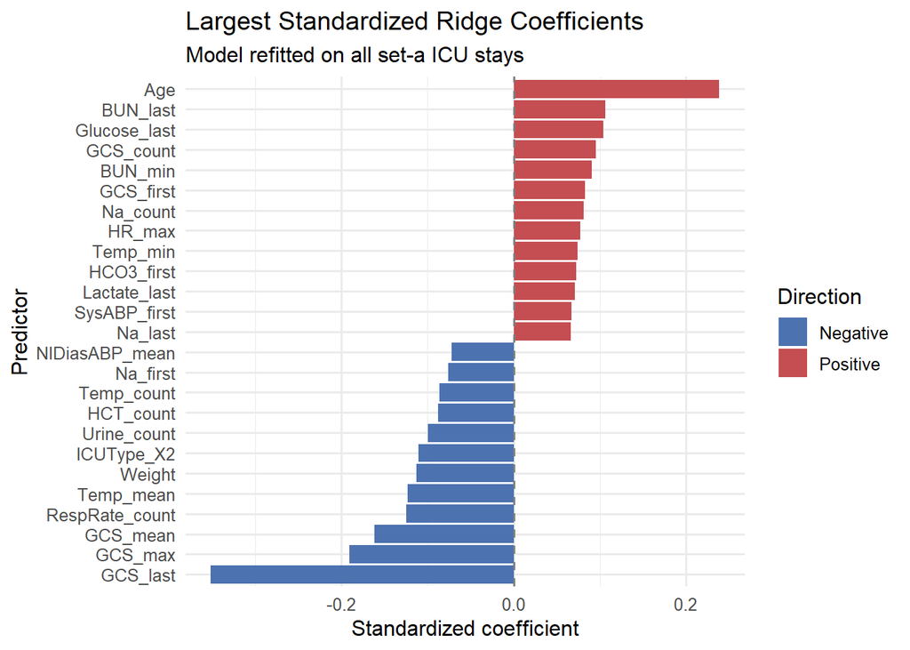

**Figure interpretation.** The largest absolute standardized ridge coefficient is for GCS_last (-0.351). Positive bars indicate higher fitted mortality log odds and negative bars lower fitted mortality log odds. GCS denotes Glasgow Coma Scale; BUN denotes blood urea nitrogen. Multiple GCS and BUN summaries are correlated; individual coefficient signs and sizes are not independent causal effects. The coefficients are shown on a common standardized scale.

## 2.5 Model 2: generalized additive model

The logistic generalized additive model (GAM) uses 15 predictors. Five smooth terms describe age, last blood urea nitrogen (BUN), last glucose, maximum heart rate and mean temperature. These retain the original exploratory model’s clinically motivated smooth structure. Eight additional numerical predictors are selected by absolute standardized ridge coefficients **within each outer training fold**; gender and ICU type are retained as categorical predictors. The full-set-a ridge fit is used only for the final descriptive refit. This corrects the previous use of full-data ridge results for cross-validation feature selection. Because set-a was explored during model development, these remain internal validation estimates.

Each spline has basis dimension four; smoothing is estimated by restricted maximum likelihood (REML) on training data. Training-fold median imputation reduces sensitivity to skewed measurements; mode imputation preserves category levels. Count predictors use a log(1 + count) transformation to reduce skew.

```
Fitting GAM fold 1 of 5
Fitting GAM fold 2 of 5
Fitting GAM fold 3 of 5
Fitting GAM fold 4 of 5
Fitting GAM fold 5 of 5
```

GAM predictors by training set

| Fold | Predictor |
| --- | --- |
| Fold1 | Age |
| Fold1 | BUN_last |
| Fold1 | Glucose_last |
| Fold1 | HR_max |
| Fold1 | Temp_mean |
| Fold1 | GCS_last |
| Fold1 | GCS_max |
| Fold1 | GCS_mean |
| Fold1 | RespRate_count |
| Fold1 | Weight |
| Fold1 | Urine_count |
| Fold1 | Temp_min |
| Fold1 | HCT_count |
| Fold1 | ICUType |
| Fold1 | Gender |
| Fold2 | Age |
| Fold2 | BUN_last |
| Fold2 | Glucose_last |
| Fold2 | HR_max |
| Fold2 | Temp_mean |
| Fold2 | GCS_last |
| Fold2 | GCS_max |
| Fold2 | GCS_mean |
| Fold2 | Weight |
| Fold2 | RespRate_count |
| Fold2 | Urine_count |
| Fold2 | Na_count |
| Fold2 | GCS_count |
| Fold2 | ICUType |
| Fold2 | Gender |

[output cut: 60 more lines]

GAM performance by fold

| Fold | N | Deaths | AUROC | Brier_score |
| --- | --- | --- | --- | --- |
| Fold1 | 801 | 111 | 0.8089 | 0.0993 |
| Fold2 | 800 | 111 | 0.8653 | 0.0901 |
| Fold3 | 800 | 111 | 0.8350 | 0.0922 |
| Fold4 | 800 | 111 | 0.8256 | 0.0978 |
| Fold5 | 799 | 110 | 0.8104 | 0.0962 |

GAM cross-validation summary

| Mean_AUROC | SD_AUROC | Mean_Brier |
| --- | --- | --- |
| 0.8291 | 0.023 | 0.0951 |

GAM achieves a mean outer-fold AUROC of 0.8291 (SD 0.0230) and a mean Brier score of 0.0951. The predictor table documents training-specific selection. Differences across folds indicate selection instability; the comparison table quantifies performance relative to ridge.

### Refit GAM on complete set-a

### GAM smooth-term summary

Smooth terms in the final GAM

| Term | edf | Ref.df | Chi.sq | p-value |
| --- | --- | --- | --- | --- |
| s(Age) | 1.001 | 1.001 | 46.149 | 0.000 |
| s(BUN_last) | 2.559 | 2.866 | 25.828 | 0.000 |
| s(Glucose_last) | 1.001 | 1.002 | 10.233 | 0.001 |
| s(HR_max) | 2.570 | 2.881 | 24.262 | 0.000 |
| s(Temp_mean) | 2.757 | 2.959 | 25.589 | 0.000 |

Effective degrees of freedom (edf) near 1 indicate approximately linear fitted terms on the log-odds scale; an edf substantially above 1 indicates a more curved fitted shape. The smooth-term p-values test association, **not nonlinearity specifically**. Here age and last glucose are near-linear, while BUN, maximum heart rate and temperature have more visibly nonlinear shapes.

```
[1] TRUE
```

### GAM partial-effect plots

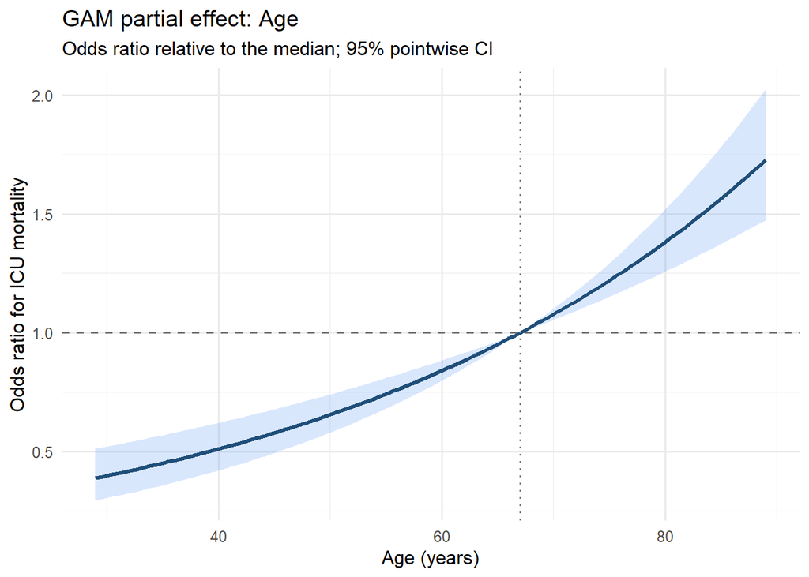

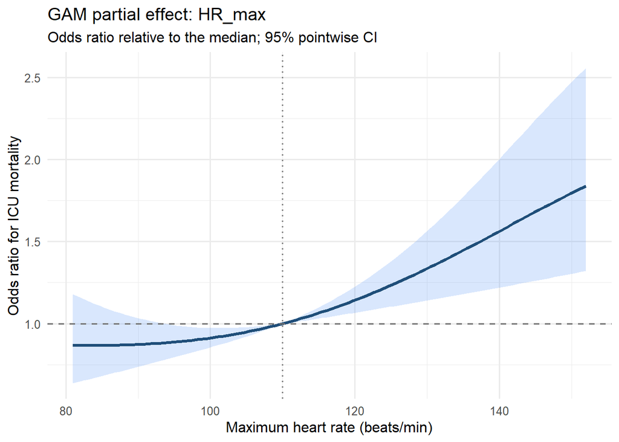

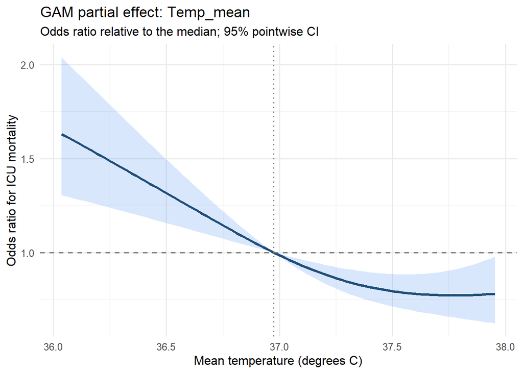

**Figure interpretation.** The age odds-ratio curve increases steadily relative to median age and is approximately linear on the log-odds scale, consistent with greater vulnerability in older ICU patients. Maximum heart rate has a nonlinear relationship: the curve is relatively flat at lower values and rises at higher values, plausibly reflecting physiological stress. Mean temperature also has a nonlinear relationship, with higher fitted mortality odds at lower temperatures and flattening toward higher temperatures; this is consistent with low temperature being a marker of severe illness, but does not establish a protective effect of raising temperature. Shaded regions are 95% **pointwise** confidence intervals (CI), and uncertainty widens at the ends of the observed ranges. These are adjusted associations rather than causal effects.

## 2.6 Model 3: random forest

I use a random forest of 300 trees to capture nonlinearities and interactions without specifying their functional forms. The number of candidate features per split (`mtry`: 10, 25 or 50) and minimum terminal-node size (`min_n`: 5 or 15) are tuned by three-fold log-loss cross-validation within each outer training fold. Missing values are imputed using each training split; predictors do not need standardization for a tree ensemble.

Random forest tuning grid

| mtry | min_n |
| --- | --- |
| 10 | 5 |
| 10 | 15 |
| 25 | 5 |
| 25 | 15 |
| 50 | 5 |
| 50 | 15 |

```
====================================
Random Forest — Fold 1 of 5
====================================

====================================
Random Forest — Fold 2 of 5
====================================

====================================
Random Forest — Fold 3 of 5
====================================

====================================
Random Forest — Fold 4 of 5
====================================

====================================
Random Forest — Fold 5 of 5
====================================
```

Random Forest performance by fold

| Fold | N | Deaths | Best_mtry | Best_min_n | AUROC | Brier_score |
| --- | --- | --- | --- | --- | --- | --- |
| Fold1 | 801 | 111 | 50 | 15 | 0.8393 | 0.0941 |
| Fold2 | 800 | 111 | 25 | 5 | 0.8501 | 0.0922 |
| Fold3 | 800 | 111 | 25 | 15 | 0.8278 | 0.0945 |
| Fold4 | 800 | 111 | 25 | 5 | 0.8382 | 0.0936 |
| Fold5 | 799 | 110 | 25 | 15 | 0.8494 | 0.0892 |

Random Forest cross-validation summary

| Mean_AUROC | SD_AUROC | Mean_Brier |
| --- | --- | --- |
| 0.8409 | 0.0092 | 0.0927 |

Random forest achieves a mean outer-fold AUROC of 0.8409 (SD 0.0092) and a mean Brier score of 0.0927. Performance is comparatively stable across the five validation folds. The tuning grid and the selected `mtry` and `min_n` for each fold are reported above.

### Tune random forest for final refitting

Random forest full-data tuning

| mtry | min_n | .metric | .estimator | mean | n | std_err | .config |
| --- | --- | --- | --- | --- | --- | --- | --- |
| 50 | 5 | mn_log_loss | binary | 0.3024 | 5 | 0.0034 | pre0_mod5_post0 |
| 50 | 15 | mn_log_loss | binary | 0.3025 | 5 | 0.0031 | pre0_mod6_post0 |
| 25 | 15 | mn_log_loss | binary | 0.3029 | 5 | 0.0032 | pre0_mod4_post0 |
| 25 | 5 | mn_log_loss | binary | 0.3040 | 5 | 0.0031 | pre0_mod3_post0 |
| 10 | 5 | mn_log_loss | binary | 0.3055 | 5 | 0.0033 | pre0_mod1_post0 |
| 10 | 15 | mn_log_loss | binary | 0.3072 | 5 | 0.0032 | pre0_mod2_post0 |

Selected random forest parameters

| mtry | min_n | .config |
| --- | --- | --- |
| 50 | 5 | pre0_mod5_post0 |

### Final random forest fit

```
[1] TRUE
```

### Permutation variable importance

Twenty most important Random Forest predictors

| Predictor | Importance |
| --- | --- |
| GCS_last | 0.0116 |
| GCS_mean | 0.0074 |
| Urine_mean | 0.0070 |
| BUN_mean | 0.0068 |
| BUN_last | 0.0065 |
| GCS_max | 0.0040 |
| BUN_min | 0.0038 |
| BUN_max | 0.0035 |
| BUN_first | 0.0024 |
| HCO3_mean | 0.0017 |
| ALP_last | 0.0015 |
| Urine_max | 0.0014 |
| Creatinine_mean | 0.0012 |
| Albumin_mean | 0.0011 |
| Age | 0.0011 |
| ALP_mean | 0.0010 |
| Bilirubin_last | 0.0010 |
| Creatinine_first | 0.0010 |
| Temp_max | 0.0010 |
| ALP_min | 0.0010 |

### Random forest importance plot

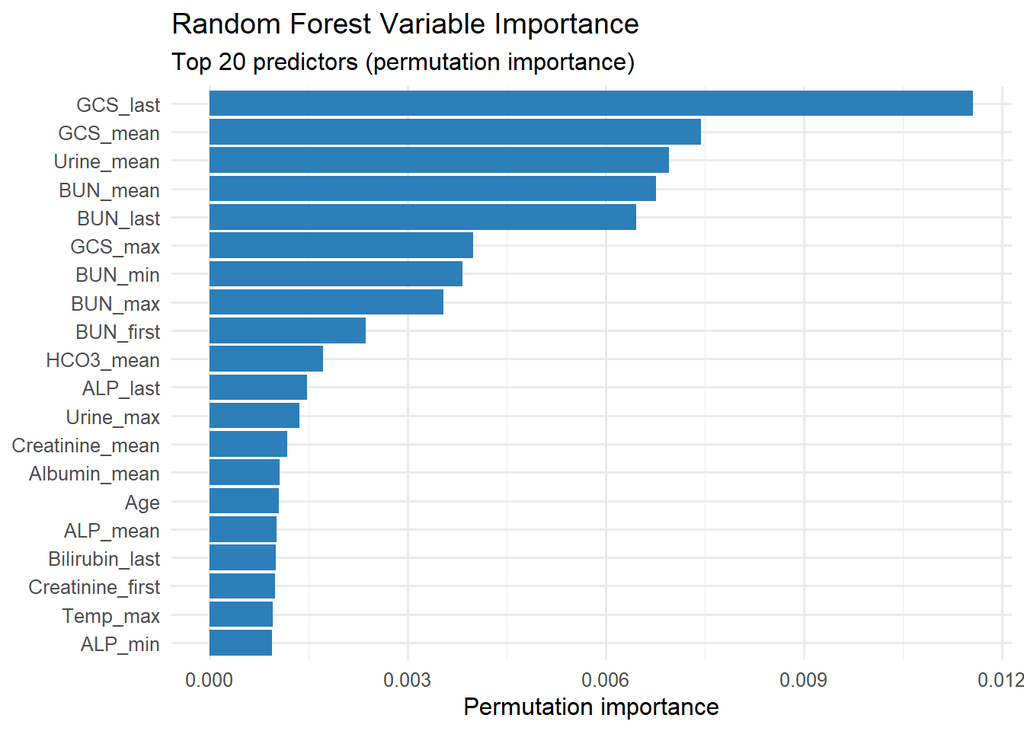

**Figure interpretation.** The three highest permutation importances are GCS_last, GCS_mean, Urine_mean. Larger importance indicates greater deterioration in out-of-bag prediction when the predictor is permuted. Their permutation importance represents predictive contribution in this fitted forest, and can be shared or unstable across correlated predictors; it does not imply causality.

## 2.7 Comparison and final model selection

For a like-for-like comparison, SAPS-I and SOFA are each used as a **single-score** logistic risk predictor. The score-to-risk logistic calibration and any score imputation are fitted separately within each outer training fold. Thus benchmark Brier scores describe fold-wise calibrated scores, rather than raw ordinal severity scores. Their ROC rankings are compared using the same validation stays and five folds as the three machine learning models.

### 2.7.0 Reproducible SAPS-I and SOFA benchmark predictions

The outcomes file supplies SAPS-I and SOFA scores. Each is evaluated separately, without including the other score or any machine-learning features. Median score imputation and the one-predictor logistic calibration are estimated only on each outer training fold and then applied to the held-out fold. This step **creates** the benchmark OOF CSV rather than relying on a file generated manually in a previous RStudio session.

Clinical score benchmarks (training-fold calibration)

| Model | Mean_AUROC | SD_AUROC | Mean_Brier |
| --- | --- | --- | --- |
| SAPS_I | 0.6460 | 0.0248 | 0.1152 |
| SOFA | 0.6198 | 0.0361 | 0.1151 |

### 2.7.1 Fold reconstruction and integrity checks

```
Original five-fold mapping loaded successfully.
```

### 2.7.2 Load standardized OOF predictions

### 2.7.3 Merge the five prediction methods

Number of out-of-fold predictions

| Model | n |
| --- | --- |
| Random Forest | 4000 |
| Ridge | 4000 |
| GAM | 4000 |
| SAPS-I | 4000 |
| SOFA | 4000 |

```
SUCCESS: All five models have 4000 aligned predictions.
```

### 2.7.4 Fold-level AUROC and Brier scores

Performance of all five methods across CV folds

| Model | Fold | N | Deaths | AUROC | Brier_score |
| --- | --- | --- | --- | --- | --- |
| Random Forest | Fold1 | 801 | 111 | 0.8393 | 0.0941 |
| Random Forest | Fold2 | 800 | 111 | 0.8501 | 0.0922 |
| Random Forest | Fold3 | 800 | 111 | 0.8278 | 0.0945 |
| Random Forest | Fold4 | 800 | 111 | 0.8382 | 0.0936 |
| Random Forest | Fold5 | 799 | 110 | 0.8494 | 0.0892 |
| Ridge | Fold1 | 801 | 111 | 0.8129 | 0.0994 |
| Ridge | Fold2 | 800 | 111 | 0.8714 | 0.0870 |
| Ridge | Fold3 | 800 | 111 | 0.8031 | 0.1002 |
| Ridge | Fold4 | 800 | 111 | 0.8379 | 0.0981 |
| Ridge | Fold5 | 799 | 110 | 0.8427 | 0.0854 |
| GAM | Fold1 | 801 | 111 | 0.8089 | 0.0993 |
| GAM | Fold2 | 800 | 111 | 0.8653 | 0.0901 |
| GAM | Fold3 | 800 | 111 | 0.8350 | 0.0922 |
| GAM | Fold4 | 800 | 111 | 0.8256 | 0.0978 |
| GAM | Fold5 | 799 | 110 | 0.8104 | 0.0962 |
| SAPS-I | Fold1 | 801 | 111 | 0.6421 | 0.1158 |
| SAPS-I | Fold2 | 800 | 111 | 0.6765 | 0.1146 |
| SAPS-I | Fold3 | 800 | 111 | 0.6374 | 0.1157 |
| SAPS-I | Fold4 | 800 | 111 | 0.6118 | 0.1175 |
| SAPS-I | Fold5 | 799 | 110 | 0.6622 | 0.1126 |
| SOFA | Fold1 | 801 | 111 | 0.6064 | 0.1170 |
| SOFA | Fold2 | 800 | 111 | 0.6591 | 0.1136 |
| SOFA | Fold3 | 800 | 111 | 0.5847 | 0.1169 |
| SOFA | Fold4 | 800 | 111 | 0.5912 | 0.1160 |
| SOFA | Fold5 | 799 | 110 | 0.6577 | 0.1122 |

### 2.7.5 Performance comparison

All five methods: fold AUROCs, mean, SD and Brier score

| Model | Mean_AUROC | SD_AUROC | Mean_Brier | Pooled_AUROC | Fold1 | Fold2 | Fold3 | Fold4 | Fold5 |
| --- | --- | --- | --- | --- | --- | --- | --- | --- | --- |
| Random Forest | 0.8409 | 0.0092 | 0.0927 | 0.8411 | 0.8393 | 0.8501 | 0.8278 | 0.8382 | 0.8494 |
| Ridge | 0.8336 | 0.0269 | 0.0940 | 0.8329 | 0.8129 | 0.8714 | 0.8031 | 0.8379 | 0.8427 |
| GAM | 0.8291 | 0.0230 | 0.0951 | 0.8287 | 0.8089 | 0.8653 | 0.8350 | 0.8256 | 0.8104 |
| SAPS-I | 0.6460 | 0.0248 | 0.1152 | 0.6443 | 0.6421 | 0.6765 | 0.6374 | 0.6118 | 0.6622 |
| SOFA | 0.6198 | 0.0361 | 0.1151 | 0.6189 | 0.6064 | 0.6591 | 0.5847 | 0.5912 | 0.6577 |

Benchmark gains versus fold variability

| Benchmark | AUROC_gain | Benchmark_SD | Candidate_SD | Larger_than_both_SDs |
| --- | --- | --- | --- | --- |
| SAPS-I | 0.1950 | 0.0248 | 0.0092 | TRUE |
| SOFA | 0.2211 | 0.0361 | 0.0092 | TRUE |

The highest mean-AUROC candidate is **Random Forest**. Its mean AUROC exceeds SAPS-I by 0.1950 and SOFA by 0.2211. The gain is larger than both methods’ fold-level SDs for 2 of the two benchmarks. This describes fold variability; it is not a formal significance test because training sets overlap.

### 2.7.6 ROC curves

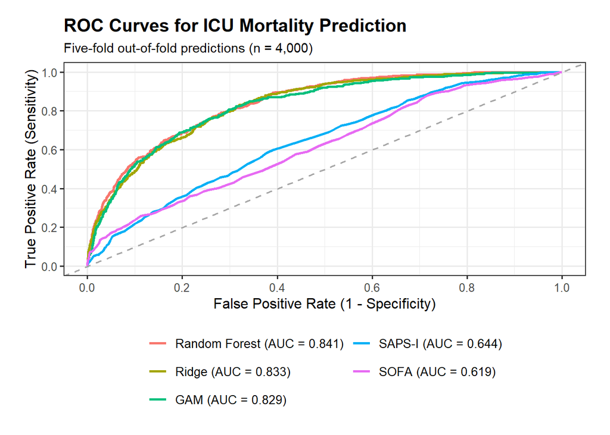

**Figure interpretation.** ROC curves show sensitivity at each false-positive rate. The pooled-AUROC ranking in the legend identifies overall discrimination; curve crossings can change which method is preferable at a particular false-positive rate. The figure legend reports *pooled* OOF AUROCs, while the comparison table reports the primary mean and SD of five held-out fold AUROCs. The two summaries need not be numerically identical.

### 2.7.7 Final model selection

```
Selected final model: Random Forest
```

```
Selected and saved model: Random Forest
```

### 2.7.8 Output verification

Checkpoint 2 final output verification

| File | Exists |
| --- | --- |
| output/cp2_all_fold_performance.csv | TRUE |
| output/cp2_model_comparison.csv | TRUE |
| output/cp2_oof_predictions.csv | TRUE |
| output/cp2_roc_all_models.png | TRUE |
| output/cp2_final_model.rds | TRUE |

```
SUCCESS: All required Section 2.7 files exist.
```

### Preprocessing exclusions across all training stages

Exact preprocessing removals and rules

| Predictor | Rule | Training_stages |
| --- | --- | --- |
| MechVent_first | Zero variance | Ridge/Fold1/Fold1; Ridge/Fold1/Fold2; Ridge/Fold1/Fold3; Ridge/Fold1/refit; Ridge/Fold2/Fold1; Ridge/Fold2/Fold2; Ridge/Fold2/Fold3; Ridge/Fold2/refit; Ridge/Fold3/Fold1; Ridge/Fold3/Fold2; Ridge/Fold… |
| MechVent_last | Zero variance | Ridge/Fold1/Fold1; Ridge/Fold1/Fold2; Ridge/Fold1/Fold3; Ridge/Fold1/refit; Ridge/Fold2/Fold1; Ridge/Fold2/Fold2; Ridge/Fold2/Fold3; Ridge/Fold2/refit; Ridge/Fold3/Fold1; Ridge/Fold3/Fold2; Ridge/Fold… |
| MechVent_max | Zero variance | Ridge/Fold1/Fold1; Ridge/Fold1/Fold2; Ridge/Fold1/Fold3; Ridge/Fold1/refit; Ridge/Fold2/Fold1; Ridge/Fold2/Fold2; Ridge/Fold2/Fold3; Ridge/Fold2/refit; Ridge/Fold3/Fold1; Ridge/Fold3/Fold2; Ridge/Fold… |
| MechVent_mean | Zero variance | Ridge/Fold1/Fold1; Ridge/Fold1/Fold2; Ridge/Fold1/Fold3; Ridge/Fold1/refit; Ridge/Fold2/Fold1; Ridge/Fold2/Fold2; Ridge/Fold2/Fold3; Ridge/Fold2/refit; Ridge/Fold3/Fold1; Ridge/Fold3/Fold2; Ridge/Fold… |
| MechVent_min | Zero variance | Ridge/Fold1/Fold1; Ridge/Fold1/Fold2; Ridge/Fold1/Fold3; Ridge/Fold1/refit; Ridge/Fold2/Fold1; Ridge/Fold2/Fold2; Ridge/Fold2/Fold3; Ridge/Fold2/refit; Ridge/Fold3/Fold1; Ridge/Fold3/Fold2; Ridge/Fold… |

The exclusion table distinguishes sparse predictors from zero-variance columns and identifies the training stages where each removal occurred. Missingness is never estimated from validation observations.

### Conclusion and limitations

The selected model is **Random Forest**, chosen by highest mean outer-fold AUROC among the three fitted candidates, with Brier score breaking ties. Its mean AUROC is 0.8409 and mean Brier score is 0.0927. Each candidate is refitted on full set-a, and the selected candidate is exported. Choosing the winner on these CV results can introduce selection optimism. Ridge is simpler and its standardized coefficients are more directly interpretable; GAM helps visualize nonlinearity. Benchmark differences are quantified above. All estimates are internal to set-a. They do not establish clinical utility or generalization to another hospital, population or period. Follow-up work should evaluate calibration, decision curves and subgroups, which are deferred to Checkpoint 3.

### Reproducibility and outputs

Only relative paths are used. All results come from the set-a patient files and `Outcomes-a.txt`; random seeds and common CV folds are defined above. The fitted preprocessing and selected model are saved as `output/cp2_final_model.rds`, alongside `output/cp2_oof_predictions.csv`, figure files and the fold-level model comparison. Generate this report from a fresh repository checkout using `pixi run --locked checkpoint2` once the environment and data are in place. The command should produce `output/checkpoint2.html`.

This execution took 7.0 minutes. Runtime and session information are saved for reproducibility.